# Replication of Task Kepler

Author

GH

## Helpers and preparations

### Set switch to do bootstrap

```r
do_bootstrap <- FALSE
do_symbolic <- FALSE
```

### Helper function to plot residuals

```r
library(ggplot2)
library(patchwork)  # for combining plots

plot_lm_diagnostics <- function(model, point=TRUE, hist=TRUE) {
  # Compute observed values
  pred <- model$fitted.values
  resid <- residuals(model)
  sresid <- rstandard(model)
  observed <- pred + resid
  sqrt_abs_sresid <- sqrt(abs(sresid))
  hatvalues <- hatvalues(model)

  # Data frame for plotting
  df <- data.frame(
    Predicted = pred,
    Observed = observed,
    Residuals = resid,
    SqrtAbsRstandard = sqrt_abs_sresid,
    hat = hatvalues
  )

  # Plot 1: Observed vs Predicted
  p1 <- ggplot(df, aes(x = Predicted, y = Observed)) +
    geom_smooth(method = "loess", formula = y ~ x, se = TRUE, color = "blue") +
    labs(title = "Observed vs. Predicted", x = "Predicted", y = "Observed") +
    theme_minimal()

  # Plot 2: Residuals vs Predicted
  p2 <- ggplot(df, aes(x = Predicted, y = Residuals)) +
    geom_smooth(method = "loess", formula = y ~ x, se = TRUE, color = "darkred") +
    geom_hline(yintercept = 0, linetype = "dashed", color = "gray50") +
    labs(title = "Residuals vs. Predicted", x = "Predicted", y = "Residuals") +
    theme_minimal()

  # Plot 3: Absolute Residuals vs Predicted
  p3 <- ggplot(df, aes(x = Predicted, y = SqrtAbsRstandard)) +
    geom_smooth(method = "loess", formula = y ~ x, se = TRUE, color = "darkgreen") +
    labs(title = "Absolute Residuals vs. Predicted", x = "Predicted", y = "sqrt(Absolute Stand. Residuals)") +
    theme_minimal()

  # Plot 5: hat values, highest 1%
  p5 <- ggplot(data=df, aes(x = hat, y = sresid)) + geom_point() + xlab("Hat values") + ylab("Standardized residuals")

  if(hist) {
    p4a <- ggplot(df, aes(x = Residuals)) + geom_histogram() + theme_minimal()
    qqn <- as.data.frame(qqnorm(df$Residuals, plot=FALSE))
    p4b <- ggplot(qqn, aes(x=x, y=y)) + geom_point() + geom_smooth() + labs(title ="Normal Q-Q Plot") + xlab("Theoretical normal quantiles") + ylab("Residuals")
    print(p4a)
    print(p4b)

  }

 if(point == T) print(p1 + geom_point())
  else print(p1)
  if(point == T) print(p2 + geom_point())
  else print(p2)
  if(point == T) print(p3 + geom_point())
  else print(p3)
 print(p5)
}
```

### Helper function for spaghetti plot

```r
library(ggplot2)
library(tidyr)
library(dplyr)
spaghetti_plot <- function(x, y_mat, y_main) {
  # Check dimensions
  if (length(x) != nrow(y_mat)) stop("Length of x must match number of rows in y_mat.")
  if (length(x) != length(y_main)) stop("Length of y_main must match length of x.")


  # Create data frame for y_mat
  df <- as.data.frame(y_mat)
  df$x <- x

  # Long format for y_mat
  df_long <- df %>%
    pivot_longer(
      cols = -x,
      names_to = "curve",
      values_to = "y"
    ) %>%
    mutate(type = "other")  # Label for color/type

  # Data frame for y_main
  df_main <- data.frame(
    x = x,
    y = y_main,
    curve = "main",
    type = "main"
  )

  # Combine data
  df_all <- bind_rows(df_long, df_main) %>%
    arrange(type, curve, x)  # Ensure proper line drawing order

  # Plot
  ggplot(df_all, aes(x = x, y = y, group = curve)) +
    geom_line(aes(color = type, size = type)) +
    scale_color_manual(values = c("main" = "black", "other" = "gray70")) +
    scale_size_manual(values = c("main" = 1.2, "other" = 0.4)) +
    theme_minimal() +
    labs(x = "X", y = "Y", title = "Spaghetti Plot of functional forms") +
    theme(legend.position = "none")  # Hide legend if not needed
}
```

#### Helper function to plot estimated functional forms

```r
# Helper function to draw spline fit nicely
library(ggplot2)

plot_glm_term <- function(pred_terms, term_name, data,
                          conf_level = 0.95, x_fun = identity) {
  # pred_terms: result from predict(glm_fit, type = "terms", se.fit = TRUE)
  # term_name: base variable name (e.g., "mass")
  # data: data.frame used for prediction
  # conf_level: confidence level for the bands
  # x_fun: transformation function for x-axis (default: identity)

  # Find the corresponding term in pred_terms$fit
  match_col <- grep(paste0("\\b", term_name, "\\b"), colnames(pred_terms$fit), value = TRUE)

  if (length(match_col) == 0) {
    stop("No matching term found in prediction output for: ", term_name)
  } else if (length(match_col) > 1) {
    warning("Multiple matching terms found. Using the first match: ", match_col[1])
  }

  matched_name <- match_col[1]

  # Get x values
  x_raw <- data[[term_name]]

  # Extract fit and standard error
  fit <- pred_terms$fit[, matched_name]
  se <- pred_terms$se.fit[, matched_name]

  # Compute confidence intervals
  z <- qnorm(1 - (1 - conf_level) / 2)
  lower <- fit - z * se
  upper <- fit + z * se

  # Prepare plot data
  plot_data <- data.frame(
    x = x_fun(x_raw),
    fit = fit,
    lower = lower,
    upper = upper
  )

  # Sort for clean plotting
  plot_data <- plot_data[order(plot_data$x), ]

  # Plot
  ggplot(plot_data, aes(x = x, y = fit)) +
    geom_line(color = "blue", linewidth = 1) +
    geom_ribbon(aes(ymin = lower, ymax = upper), fill = "blue", alpha = 0.2) +
    labs(
      title = paste("Partial Effect of", term_name),
      y = "Partial Fit (on link scale)",
      x = term_name
    ) +
    theme_minimal()
}
```

## Data set

```r
Kepler_url <- url("https://raw.githubusercontent.com/OpenExoplanetCatalogue/oec_tables/master/comma_separated/open_exoplanet_catalogue.txt")
Kepler_data <- read.csv(Kepler_url)
```

## Define Initial Data Analysis plan

### Main analysis of interest

#### Outcome variable

- semimajoraxis

#### Main predictors

- hoststar_mass
- period

#### Further candidate predictors

- mass
- binaryflag
- radius
- eccentricity
- periastron
- longitude
- ascendingnode
- inclination
- temperature
- system_rightascension
- system_declination
- hoststar_radius
- hoststar_metallicity
- hoststar_temperature

#### Structural or irrelevant variables

- discoverymethod
- discoveryyear
- lastupdate
- system_distance
- age
- hoststar_age
- list

```r
# define variable groups

main_predictors <- c("hoststar_mass", "period")
candidate_predictors <- c("mass","binaryflag","radius","eccentricity","periastron","longitude",
"ascendingnode","inclination","temperature","system_rightascension","system_declination","hoststar_radius",
"hoststar_metallicity","hoststar_temperature")
structural <- c("discoverymethod","discoveryyear","lastupdate","system_distance","age","hoststar_age","list")
system_var <- c("system_rightascension", "system_declination", "system_distance", "hoststar_mass", "hoststar_radius", "hoststar_metallicity", "hoststar_temperature", "hoststar_age")
```

## IDA

### Missing values

#### Per variable

```r
mean(is.na(Kepler_data$semimajoraxis))
```

```
[1] 0.4804211
```

```r
miss_var <- function(var) {
  ret <- sapply(1:length(var), function(X) mean(is.na(Kepler_data[,X])))
  names(ret) <- var
  ret <- ret[order(ret)]
  return(ret)
}

miss_main <- miss_var(main_predictors)
miss_candidate <- miss_var(candidate_predictors)
miss_structural <- miss_var(structural)
miss_main
```

```
hoststar_mass        period
            0             0
```

```r
miss_candidate
```

```
                 mass            binaryflag  hoststar_temperature
           0.00000000            0.00000000            0.00000000
           periastron          eccentricity             longitude
           0.05688955            0.23051348            0.48042113
               radius         ascendingnode    system_declination
           0.48707056            0.59826376            0.68304396
      hoststar_radius           inclination system_rightascension
           0.69782047            0.81289250            0.99039527
          temperature  hoststar_metallicity
           0.99205763            0.99926117
```

```r
miss_structural
```

```
discoverymethod   discoveryyear             age system_distance    hoststar_age
     0.00000000      0.00000000      0.05688955      0.23051348      0.48042113
     lastupdate            list
     0.48707056      0.59826376
```

#### Complete cases if considering different groups of predictors

```r
cat("Main predictors:", sum(complete.cases(Kepler_data[,c("semimajoraxis", main_predictors)])))
```

```
Main predictors: 2519
```

```r
cat("\nCandidate predictors:", sum(complete.cases(Kepler_data[,c("semimajoraxis", main_predictors, candidate_predictors)])))
```

```
Candidate predictors: 4
```

```r
# probably work through candidate predictor list starting with variable with smallest proportion missingness

varlist <- c("semimajoraxis", names(miss_main), names(miss_candidate), names(miss_structural))

comp_cases <- sapply(1:length(varlist), function(X) sum(complete.cases(Kepler_data[,varlist[1:X]])))
names(comp_cases) <- paste("+", varlist)
comp_cases
```

```
        + semimajoraxis         + hoststar_mass                + period
                   2813                    2703                    2519
                 + mass            + binaryflag  + hoststar_temperature
                   2120                    2120                    2016
           + periastron          + eccentricity             + longitude
                    811                     807                      29
               + radius         + ascendingnode    + system_declination
                     10                      10                      10
      + hoststar_radius           + inclination + system_rightascension
                     10                      10                      10
          + temperature  + hoststar_metallicity       + discoverymethod
                      4                       4                       4
        + discoveryyear                   + age       + system_distance
                      1                       0                       0
         + hoststar_age            + lastupdate                  + list
                      0                       0                       0
```

### Univariate distributions

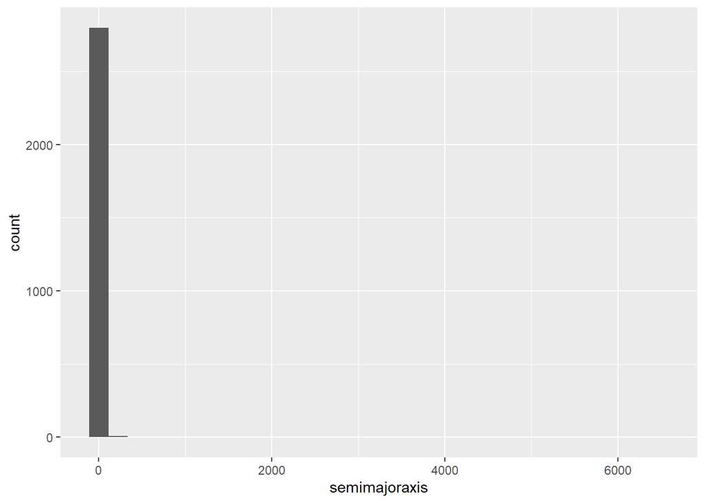

```r
library(ggplot2)

ggplot(data=Kepler_data, aes(x=semimajoraxis)) + geom_histogram()
```

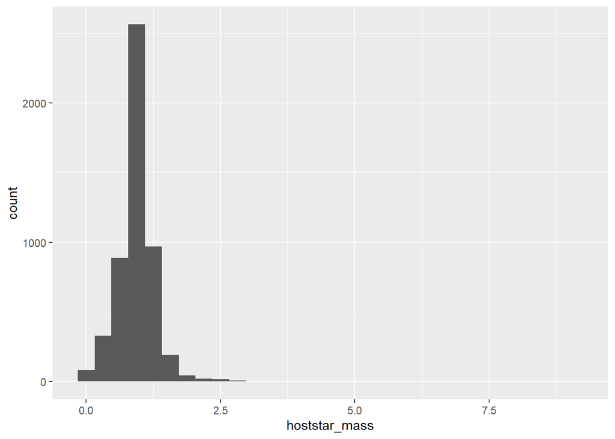

```r
ggplot(data=Kepler_data, aes(x=hoststar_mass)) + geom_histogram()
```

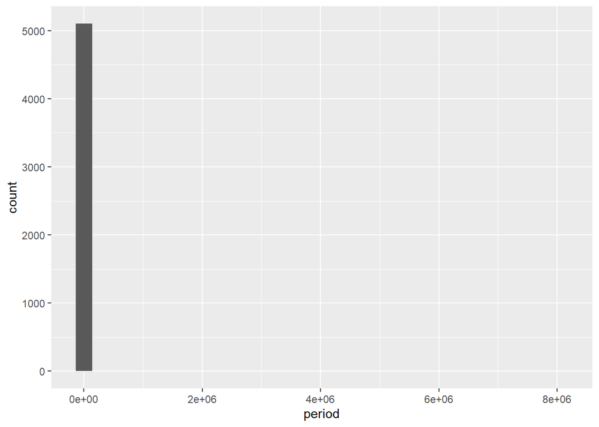

```r
ggplot(data=Kepler_data, aes(x=period)) + geom_histogram()
```

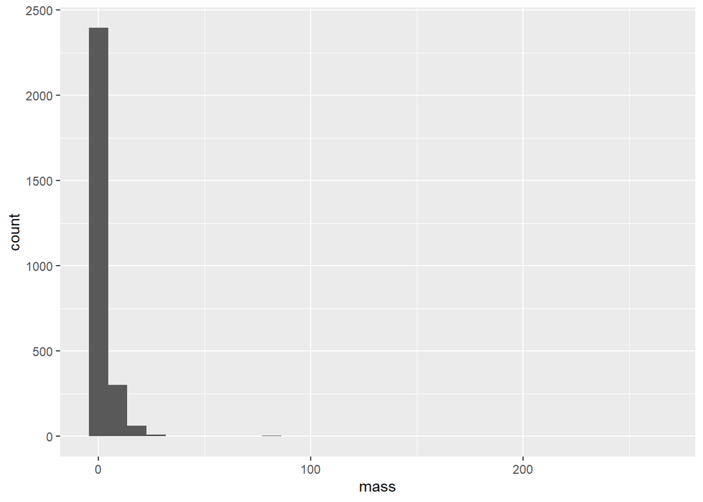

```r
ggplot(data=Kepler_data, aes(x=mass)) + geom_histogram()
```

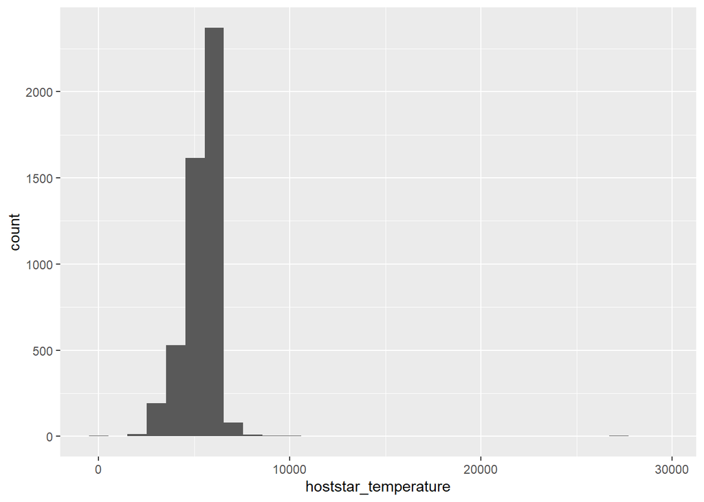

```r
ggplot(data=Kepler_data, aes(x=hoststar_temperature)) + geom_histogram()
```

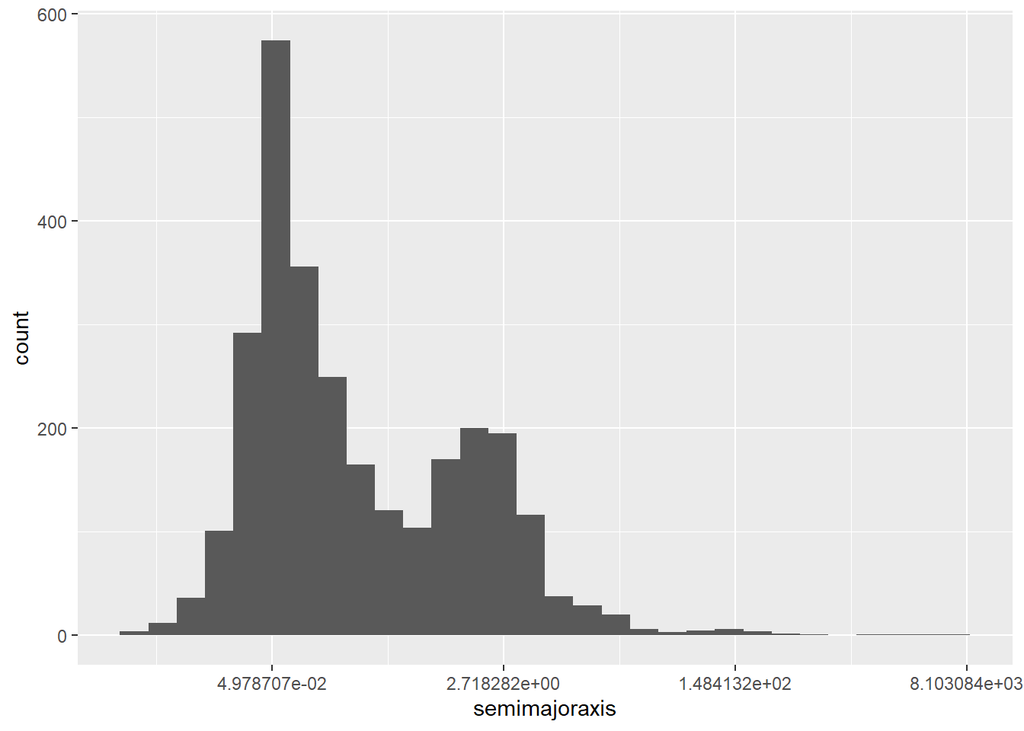

```r
ggplot(data=Kepler_data, aes(x=semimajoraxis)) + geom_histogram() +
  scale_x_continuous(transform="log")
```

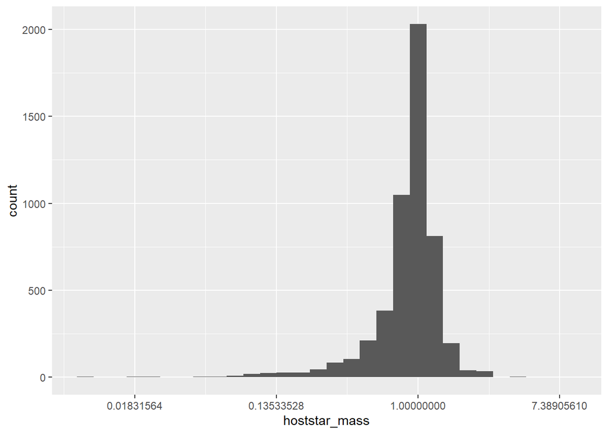

```r
ggplot(data=Kepler_data, aes(x=hoststar_mass)) + geom_histogram() + scale_x_continuous(transform="log")
```

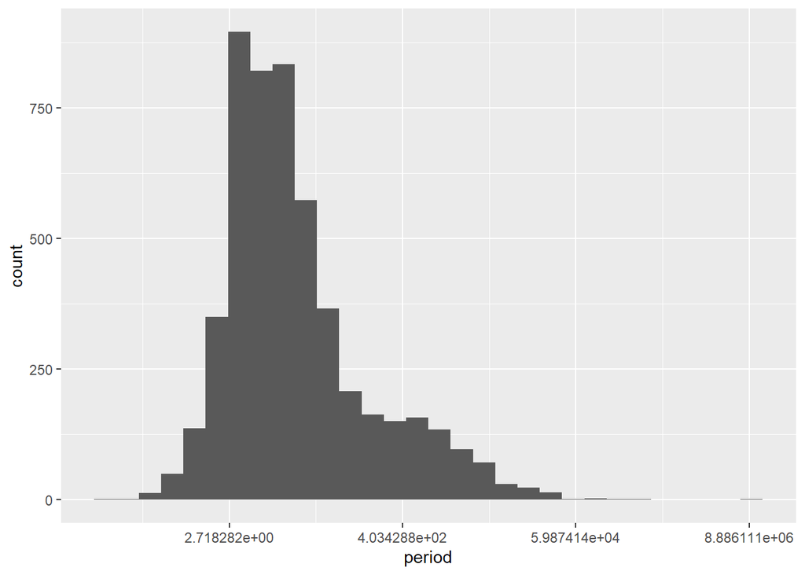

```r
ggplot(data=Kepler_data, aes(x=period)) + geom_histogram() + scale_x_continuous(transform="log")
```

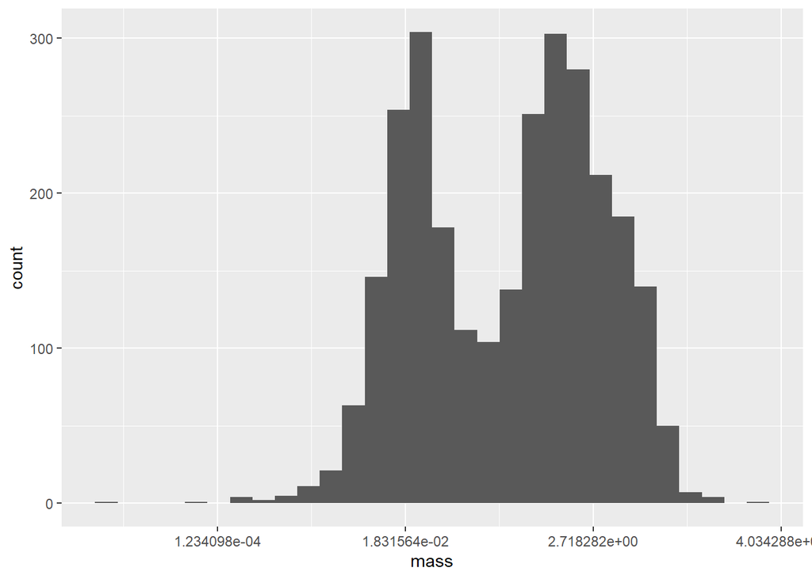

```r
ggplot(data=Kepler_data, aes(x=mass)) + geom_histogram()+ scale_x_continuous(transform="log")
```

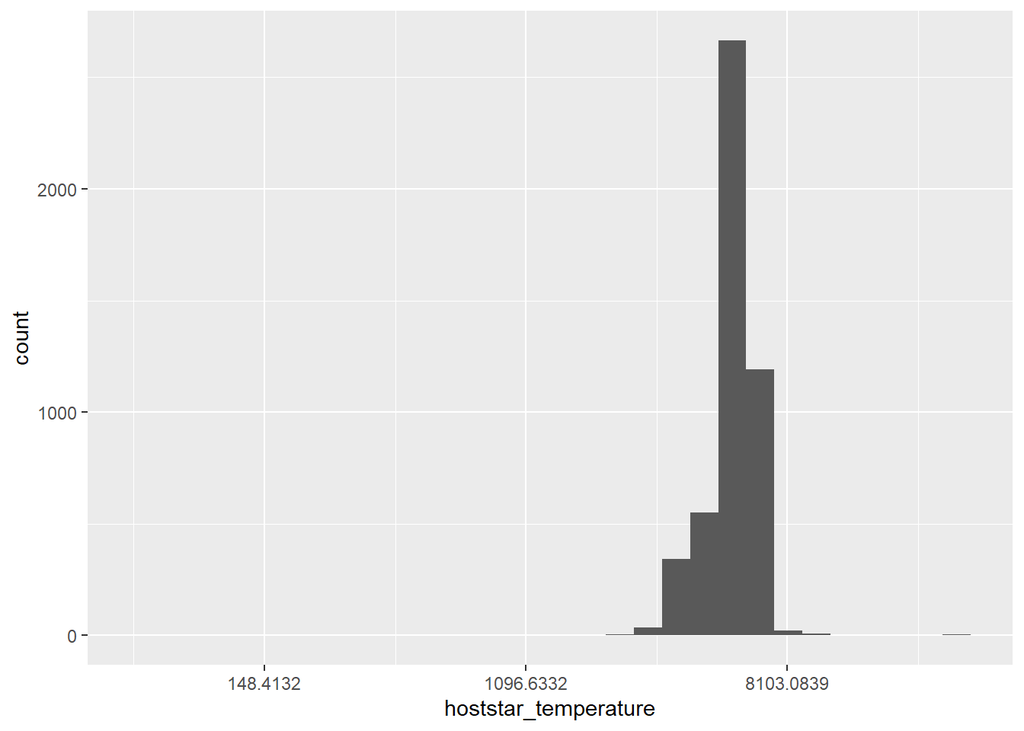

```r
ggplot(data=Kepler_data, aes(x=hoststar_temperature)) + geom_histogram()+ scale_x_continuous(transform="log")
```

### Correlations

```r
varlist <- c("semimajoraxis","mass", "radius", "period", "eccentricity", "hoststar_mass", "hoststar_radius", "hoststar_metallicity","hoststar_temperature","binaryflag")

Kepler_data_focus <- Kepler_data %>% select(semimajoraxis,mass, radius, period, eccentricity, hoststar_mass, hoststar_radius, hoststar_metallicity,hoststar_temperature,binaryflag) %>% na.omit()
summary(Kepler_data_focus)
```

```
 semimajoraxis           mass              radius            period
 Min.   : 0.00916   Min.   : 0.00001   Min.   :0.01644   Min.   :     0.45
 1st Qu.: 0.04328   1st Qu.: 0.02541   1st Qu.:0.22626   1st Qu.:     3.35
 Median : 0.06010   Median : 0.27300   Median :0.85600   Median :     5.32
 Mean   : 0.78890   Mean   : 1.27930   Mean   :0.76944   Mean   :  1047.36
 3rd Qu.: 0.13000   3rd Qu.: 1.05700   3rd Qu.:1.19000   3rd Qu.:    18.36
 Max.   :67.96000   Max.   :79.00000   Max.   :2.08500   Max.   :166510.00
  eccentricity      hoststar_mass   hoststar_radius  hoststar_metallicity
 Min.   :-0.12929   Min.   :0.089   Min.   : 0.121   Min.   :-0.92000
 1st Qu.: 0.00000   1st Qu.:0.840   1st Qu.: 0.820   1st Qu.:-0.06000
 Median : 0.00380   Median :1.000   Median : 1.020   Median : 0.06000
 Mean   : 0.08658   Mean   :1.001   Mean   : 1.309   Mean   : 0.05242
 3rd Qu.: 0.10938   3rd Qu.:1.173   3rd Qu.: 1.400   3rd Qu.: 0.18100
 Max.   : 0.93369   Max.   :2.820   Max.   :86.400   Max.   : 7.79000
 hoststar_temperature   binaryflag
 Min.   :2516         Min.   :0.00000
 1st Qu.:5078         1st Qu.:0.00000
 Median :5645         Median :0.00000
 Mean   :5472         Mean   :0.05538
 3rd Qu.:6000         3rd Qu.:0.00000
 Max.   :9360         Max.   :2.00000
```

```r
cor(Kepler_data_focus[,varlist[-1]], method="spearman", use="pairwise.complete")
```

```
                           mass     radius       period eccentricity
mass                  1.0000000  0.8350400 -0.059935397  0.282019517
radius                0.8350400  1.0000000 -0.207738345  0.116096807
period               -0.0599354 -0.2077383  1.000000000  0.323707938
eccentricity          0.2820195  0.1160968  0.323707938  1.000000000
hoststar_mass         0.4843752  0.5569661  0.001105862  0.035605872
hoststar_radius       0.4450308  0.5250935  0.017865377  0.028098943
hoststar_metallicity  0.2269254  0.2024591 -0.098534650  0.080349473
hoststar_temperature  0.3646058  0.4488072 -0.021143030 -0.057541835
binaryflag            0.1273242  0.1315511 -0.110982104  0.006674302
                     hoststar_mass hoststar_radius hoststar_metallicity
mass                   0.484375192      0.44503081          0.226925350
radius                 0.556966124      0.52509351          0.202459140
period                 0.001105862      0.01786538         -0.098534650
eccentricity           0.035605872      0.02809894          0.080349473
hoststar_mass          1.000000000      0.92932270          0.205804430
hoststar_radius        0.929322696      1.00000000          0.143535137
hoststar_metallicity   0.205804430      0.14353514          1.000000000
hoststar_temperature   0.868993557      0.79263223          0.001889472
binaryflag             0.094441532      0.07494805          0.025708099
                     hoststar_temperature   binaryflag
mass                          0.364605828  0.127324225
radius                        0.448807224  0.131551147
period                       -0.021143030 -0.110982104
eccentricity                 -0.057541835  0.006674302
hoststar_mass                 0.868993557  0.094441532
hoststar_radius               0.792632230  0.074948052
hoststar_metallicity          0.001889472  0.025708099
hoststar_temperature          1.000000000  0.088019746
binaryflag                    0.088019746  1.000000000
```

## Analyses according to SAP

### Analysis sets

We create an analysis set with original data and one with log-transformed data. For the log-transformation, we add constants to eccentricity and to hoststar_metallicity, because their smalles values are less than 0. binaryflag is not tansformed.

```r
analysis_set <- Kepler_data_focus
analysis_set <- analysis_set[complete.cases(analysis_set),]

analysis_set_tmp <- analysis_set
analysis_set_tmp$eccentricity <- analysis_set_tmp$eccentricity + 0.13
analysis_set_tmp$hoststar_metallicity <- analysis_set_tmp$hoststar_metallicity + 1
analysis_set_tmp$binaryflag <- exp(analysis_set_tmp$binaryflag) # to ensure that after log transforamtion, we still have original values.
analysis_log <- log(analysis_set_tmp)
```

```r
formula <- as.formula(paste0("semimajoraxis ~", paste(varlist[-1], collapse="+")))

fit_M1_global <- lm(data=analysis_set, formula=formula)
fit_M1 <- step(fit_M1_global, direction="both", k=log(nrow(analysis_set)))
```

```
Start:  AIC=-162.72
semimajoraxis ~ mass + radius + period + eccentricity + hoststar_mass +
    hoststar_radius + hoststar_metallicity + hoststar_temperature +
    binaryflag

                       Df Sum of Sq     RSS     AIC
- hoststar_mass         1       0.2   734.3 -169.30
- hoststar_radius       1       0.5   734.6 -168.94
- hoststar_temperature  1       1.0   735.1 -168.32
- radius                1       1.8   735.9 -167.27
- binaryflag            1       2.3   736.3 -166.69
- hoststar_metallicity  1       2.8   736.9 -165.97
<none>                                734.1 -162.72
- eccentricity          1      19.4   753.5 -145.01
- mass                  1      64.2   798.3  -90.79
- period                1   12227.0 12961.0 2526.37

Step:  AIC=-169.3
semimajoraxis ~ mass + radius + period + eccentricity + hoststar_radius +
    hoststar_metallicity + hoststar_temperature + binaryflag

                       Df Sum of Sq     RSS     AIC
- hoststar_radius       1       0.3   734.6 -175.78
- hoststar_temperature  1       1.3   735.6 -174.52
- binaryflag            1       2.2   736.5 -173.28
- radius                1       2.4   736.7 -173.10
- hoststar_metallicity  1       2.6   736.9 -172.79
<none>                                734.3 -169.30
+ hoststar_mass         1       0.2   734.1 -162.72
- eccentricity          1      20.3   754.6 -150.58
- mass                  1      64.3   798.6  -97.33
- period                1   12226.9 12961.2 2519.54

Step:  AIC=-175.78
semimajoraxis ~ mass + radius + period + eccentricity + hoststar_metallicity +
    hoststar_temperature + binaryflag

                       Df Sum of Sq     RSS     AIC
- hoststar_temperature  1       1.2   735.8 -181.05
- binaryflag            1       2.2   736.8 -179.77
```

[output cut: 55 more lines]

```

Step:  AIC=-194.75
semimajoraxis ~ mass + period + eccentricity

                       Df Sum of Sq     RSS     AIC
<none>                                741.2 -194.75
+ hoststar_metallicity  1       2.1   739.1 -190.58
+ binaryflag            1       1.9   739.3 -190.35
+ hoststar_temperature  1       0.5   740.6 -188.60
+ radius                1       0.5   740.6 -188.59
+ hoststar_mass         1       0.2   740.9 -188.21
+ hoststar_radius       1       0.2   741.0 -188.10
- eccentricity          1      19.9   761.1 -176.66
- mass                  1      73.6   814.8 -112.65
- period                1   12481.9 13223.1 2504.10
```

```r
summary(fit_M1)
```

```
Call:
lm(formula = semimajoraxis ~ mass + period + eccentricity, data = analysis_set)

Residuals:
     Min       1Q   Median       3Q      Max
-11.7374  -0.1893  -0.0994  -0.0322   6.5068

Coefficients:
              Estimate Std. Error t value Pr(>|t|)
(Intercept)  1.040e-01  3.410e-02   3.050  0.00235 **
mass         8.011e-02  8.312e-03   9.638  < 2e-16 ***
period       4.756e-04  3.790e-06 125.482  < 2e-16 ***
eccentricity 9.734e-01  1.941e-01   5.016 6.32e-07 ***
---
Signif. codes:  0 '***' 0.001 '**' 0.01 '*' 0.05 '.' 0.1 ' ' 1

Residual standard error: 0.8903 on 935 degrees of freedom
Multiple R-squared:  0.9478,    Adjusted R-squared:  0.9476
F-statistic:  5654 on 3 and 935 DF,  p-value: < 2.2e-16
```

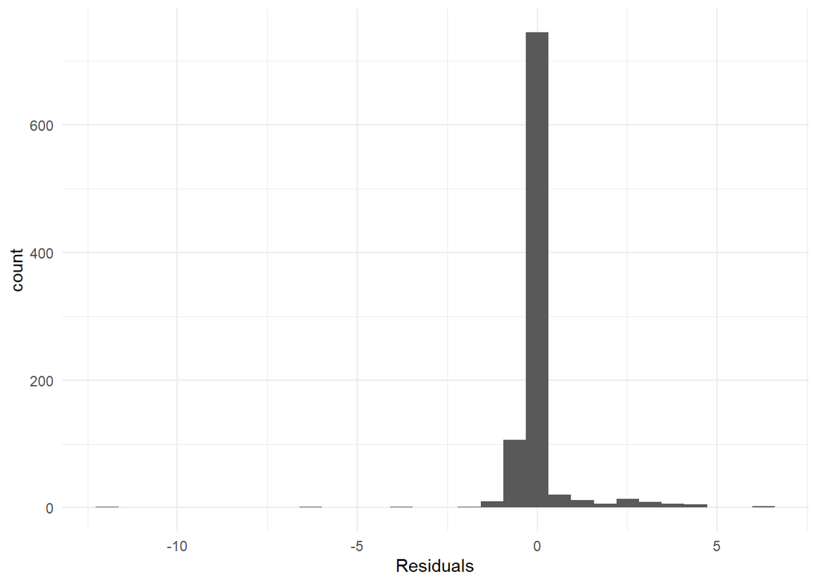

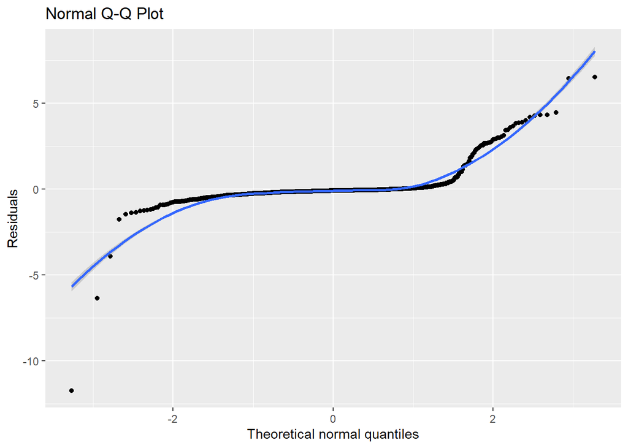

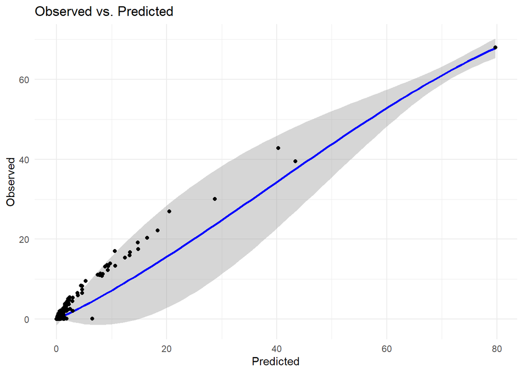

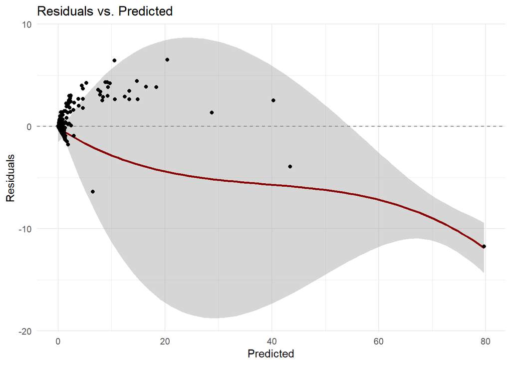

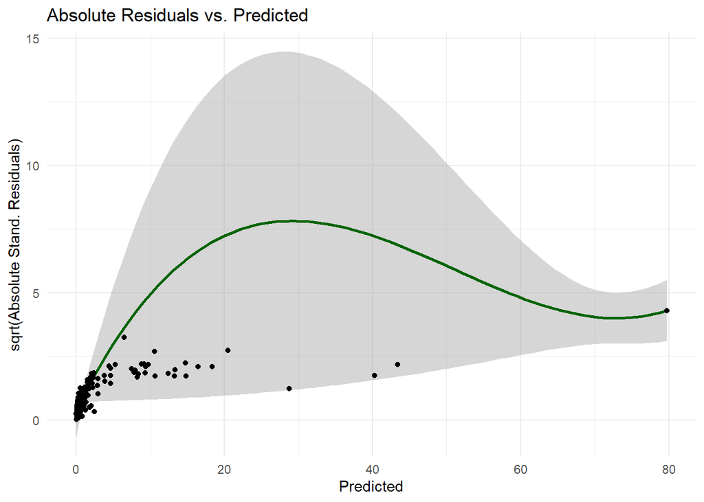

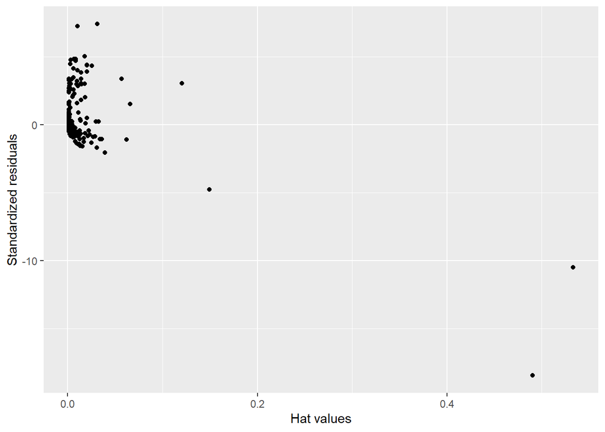

```r
plot_lm_diagnostics(fit_M1)
```

```r
# the leverage plot suggests to remove observations 666 and 2168 for their extreme leverages.
```

The leverage plot suggests that there are probably two observations with extreme leverages. Leverages (a/k/a hat values) should sum up to 4 and two observations have values greater than 0.4, which seems disproportionally high. This would suggest to remove these observations for their extreme leverages.

```r
rbind(analysis_set[hatvalues(fit_M1)>0.4,],
apply(analysis_set, 2, quantile, c(0.9, 0.99, 1)))
```

```
     semimajoraxis    mass radius       period eccentricity hoststar_mass
143       67.96000  5.0000 0.7000 1.665100e+05    0.0000000        1.5160
1637       0.07860 79.0000 0.9600 7.258448e+00    0.0250000        1.1540
90%        0.46772  3.1928 1.4282 1.183930e+02    0.2614544        1.3400
99%       16.90298 12.8962 1.8662 2.568357e+04    0.7413023        1.7762
100%      67.96000 79.0000 2.0850 1.665100e+05    0.9336900        2.8200
     hoststar_radius hoststar_metallicity hoststar_temperature binaryflag
143            1.440             -0.47000              7193.00          0
1637           1.764              0.16900              5670.00          0
90%            1.750              0.28000              6298.40          0
99%            4.141              0.43962              7381.08          2
100%          86.400              7.79000              9360.00          2
```

```r
# it seems 666 has an extreme mass und 2168 an extreme semimajoraxis
```

The analysis is now repeated with these two influential observations removed, to yield the ‘robust’ model Model 1rob.

### Model 1 rob: two influential observations removed

```r
analysis_rob <- analysis_set[hatvalues(fit_M1)<0.4,]

fit_M1_rob_global <- lm(data=analysis_rob, formula)
fit_M1_rob <- step(fit_M1_rob_global, direction="both", k=log(nrow(analysis_rob)))
```

```
Start:  AIC=-710.84
semimajoraxis ~ mass + radius + period + eccentricity + hoststar_mass +
    hoststar_radius + hoststar_metallicity + hoststar_temperature +
    binaryflag

                       Df Sum of Sq    RSS     AIC
- radius                1       0.2  408.1 -717.33
- binaryflag            1       1.2  409.1 -714.86
- hoststar_mass         1       1.4  409.3 -714.48
- hoststar_metallicity  1       2.2  410.1 -712.67
- hoststar_temperature  1       2.6  410.5 -711.65
- eccentricity          1       3.0  410.9 -710.86
<none>                               407.9 -710.84
- hoststar_radius       1       5.6  413.5 -704.82
- mass                  1      91.5  499.4 -528.05
- period                1    7327.8 7735.7 2039.52

Step:  AIC=-717.33
semimajoraxis ~ mass + period + eccentricity + hoststar_mass +
    hoststar_radius + hoststar_metallicity + hoststar_temperature +
    binaryflag

                       Df Sum of Sq    RSS     AIC
- hoststar_mass         1       1.2  409.3 -721.31
- binaryflag            1       1.3  409.4 -721.09
- hoststar_metallicity  1       2.3  410.3 -718.93
- hoststar_temperature  1       2.6  410.6 -718.28
<none>                               408.1 -717.33
- eccentricity          1       3.0  411.1 -717.27
- hoststar_radius       1       5.5  413.5 -711.66
+ radius                1       0.2  407.9 -710.84
- mass                  1      96.0  504.1 -526.13
- period                1    7370.3 7778.4 2037.83

Step:  AIC=-721.31
semimajoraxis ~ mass + period + eccentricity + hoststar_radius +
    hoststar_metallicity + hoststar_temperature + binaryflag

                       Df Sum of Sq    RSS     AIC
- binaryflag            1       1.2  410.5 -725.32
```

[output cut: 41 more lines]

```

Step:  AIC=-730.33
semimajoraxis ~ mass + period + eccentricity + hoststar_radius

                       Df Sum of Sq    RSS     AIC
<none>                               414.4 -730.33
- eccentricity          1       3.3  417.7 -729.65
- hoststar_radius       1       3.8  418.1 -728.65
+ hoststar_temperature  1       2.1  412.2 -728.29
+ hoststar_metallicity  1       1.9  412.5 -727.81
+ binaryflag            1       1.5  412.8 -726.93
+ radius                1       0.8  413.5 -725.33
+ hoststar_mass         1       0.8  413.6 -725.27
- mass                  1      95.6  509.9 -542.74
- period                1    7455.0 7869.4 2021.36
```

```r
summary(fit_M1_rob)
```

```
Call:
lm(formula = semimajoraxis ~ mass + period + eccentricity + hoststar_radius,
    data = analysis_rob)

Residuals:
    Min      1Q  Median      3Q     Max
-8.8851 -0.1505 -0.0479  0.0292  4.8368

Coefficients:
                  Estimate Std. Error t value Pr(>|t|)
(Intercept)      7.168e-02  2.660e-02   2.695  0.00717 **
mass             1.469e-01  1.002e-02  14.660  < 2e-16 ***
period           5.325e-04  4.112e-06 129.492  < 2e-16 ***
eccentricity     4.110e-01  1.500e-01   2.741  0.00625 **
hoststar_radius -2.206e-02  7.560e-03  -2.917  0.00361 **
---
Signif. codes:  0 '***' 0.001 '**' 0.01 '*' 0.05 '.' 0.1 ' ' 1

Residual standard error: 0.6668 on 932 degrees of freedom
Multiple R-squared:  0.9572,    Adjusted R-squared:  0.957
F-statistic:  5205 on 4 and 932 DF,  p-value: < 2.2e-16
```

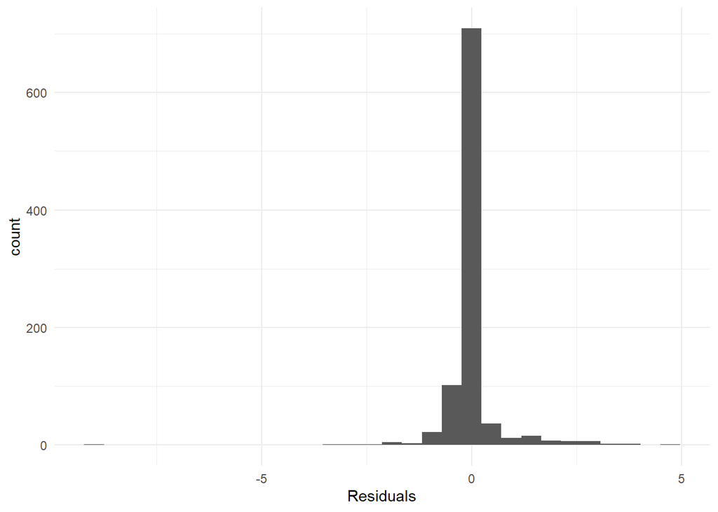

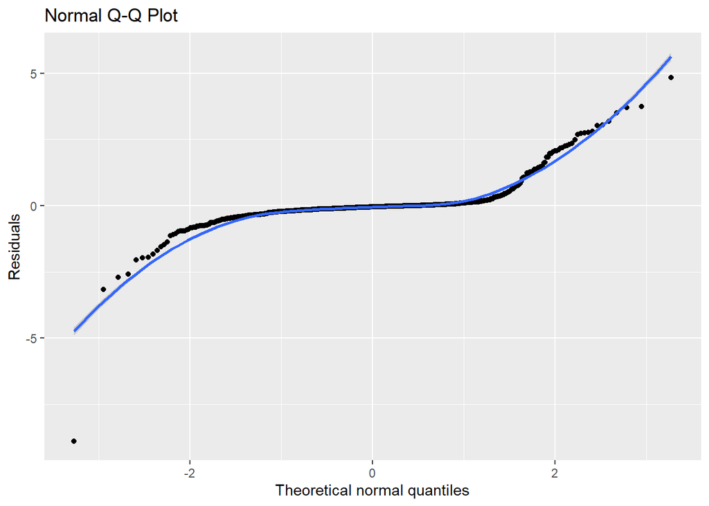

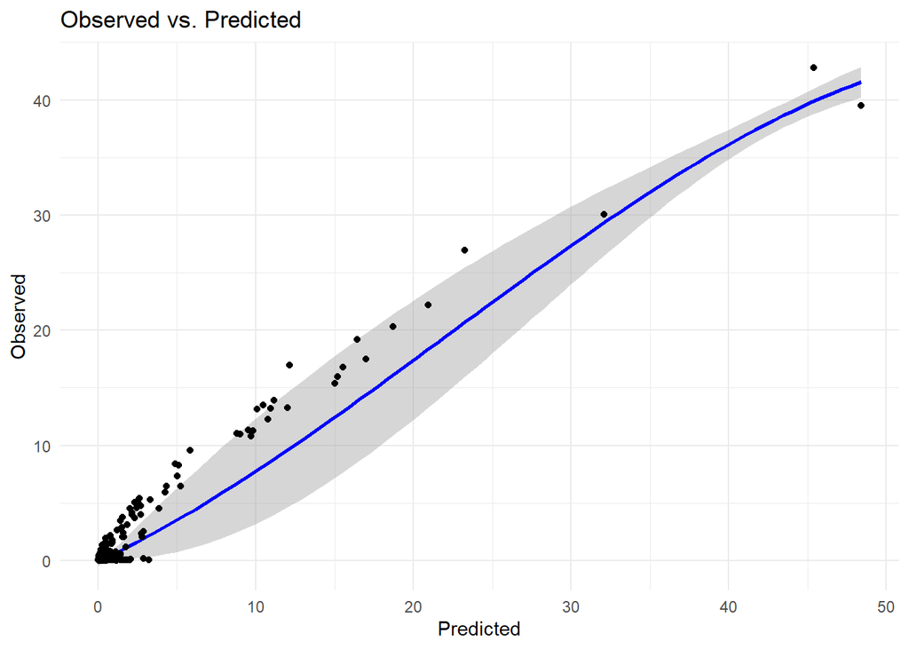

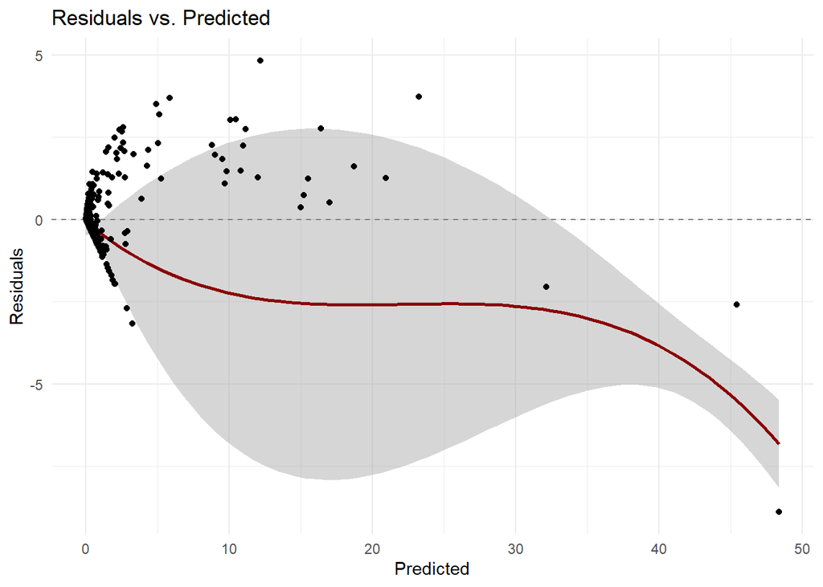

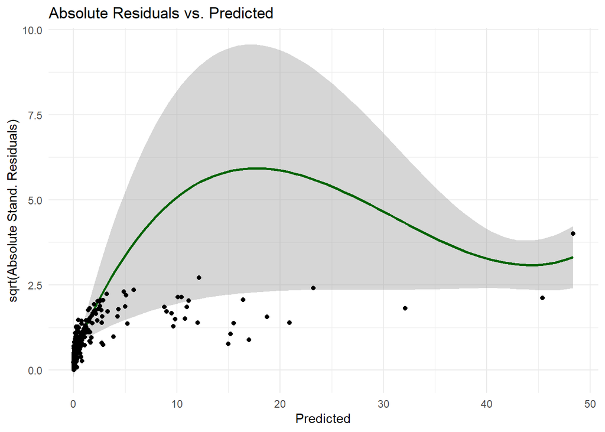

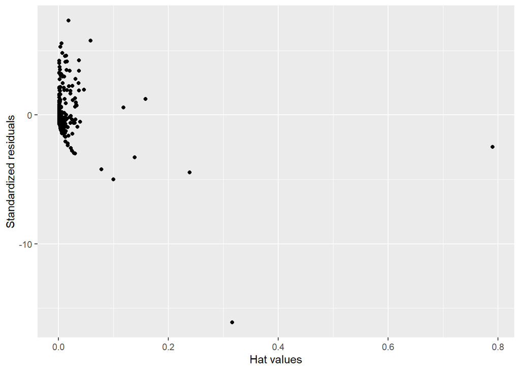

```r
plot_lm_diagnostics(fit_M1_rob)
```

The residual plots, in particular the scale-location plot indicate that the model might still need some modification.

### Model 2: backward elimination with BIC and log-transformed data

```r
fit_M2_global <- lm(data=analysis_log, formula)
fit_M2 <- step(fit_M2_global, direction="both", k=log(nrow(analysis_set)))
```

```
Start:  AIC=-5695.4
semimajoraxis ~ mass + radius + period + eccentricity + hoststar_mass +
    hoststar_radius + hoststar_metallicity + hoststar_temperature +
    binaryflag

                       Df Sum of Sq     RSS     AIC
- binaryflag            1      0.00    2.03 -5702.1
- radius                1      0.00    2.03 -5701.5
- eccentricity          1      0.00    2.03 -5701.4
- mass                  1      0.00    2.03 -5701.0
- hoststar_temperature  1      0.01    2.03 -5699.2
- hoststar_metallicity  1      0.01    2.04 -5698.3
- hoststar_radius       1      0.01    2.04 -5697.0
<none>                                 2.03 -5695.4
- hoststar_mass         1      0.86    2.89 -5368.7
- period                1   1480.94 1482.97   490.7

Step:  AIC=-5702.15
semimajoraxis ~ mass + radius + period + eccentricity + hoststar_mass +
    hoststar_radius + hoststar_metallicity + hoststar_temperature

                       Df Sum of Sq     RSS     AIC
- radius                1      0.00    2.03 -5708.2
- eccentricity          1      0.00    2.03 -5708.2
- mass                  1      0.00    2.03 -5707.7
- hoststar_temperature  1      0.01    2.03 -5705.9
- hoststar_metallicity  1      0.01    2.04 -5705.0
- hoststar_radius       1      0.01    2.04 -5703.7
<none>                                 2.03 -5702.1
+ binaryflag            1      0.00    2.03 -5695.4
- hoststar_mass         1      0.86    2.89 -5375.5
- period                1   1494.15 1496.18   492.2

Step:  AIC=-5708.19
semimajoraxis ~ mass + period + eccentricity + hoststar_mass +
    hoststar_radius + hoststar_metallicity + hoststar_temperature

                       Df Sum of Sq     RSS     AIC
- mass                  1      0.00    2.03 -5714.5
- eccentricity          1      0.00    2.03 -5714.4
```

[output cut: 70 more lines]

```

Step:  AIC=-5733.71
semimajoraxis ~ period + hoststar_mass

                       Df Sum of Sq     RSS     AIC
<none>                                 2.05 -5733.7
+ hoststar_radius       1      0.01    2.04 -5729.3
+ hoststar_metallicity  1      0.00    2.04 -5728.5
+ mass                  1      0.00    2.05 -5727.6
+ hoststar_temperature  1      0.00    2.05 -5727.2
+ radius                1      0.00    2.05 -5727.1
+ eccentricity          1      0.00    2.05 -5727.1
+ binaryflag            1      0.00    2.05 -5726.9
- hoststar_mass         1     15.13   17.18 -3743.4
- period                1   1845.50 1847.54   649.2
```

```r
summary(fit_M2)
```

```
Call:
lm(formula = semimajoraxis ~ period + hoststar_mass, data = analysis_log)

Residuals:
     Min       1Q   Median       3Q      Max
-0.80344 -0.00192 -0.00060  0.00064  0.48744

Coefficients:
               Estimate Std. Error  t value Pr(>|t|)
(Intercept)   -3.933243   0.002342 -1679.68   <2e-16 ***
period         0.666831   0.000726   918.45   <2e-16 ***
hoststar_mass  0.332248   0.003995    83.16   <2e-16 ***
---
Signif. codes:  0 '***' 0.001 '**' 0.01 '*' 0.05 '.' 0.1 ' ' 1

Residual standard error: 0.04677 on 936 degrees of freedom
Multiple R-squared:  0.9989,    Adjusted R-squared:  0.9989
F-statistic: 4.322e+05 on 2 and 936 DF,  p-value: < 2.2e-16
```

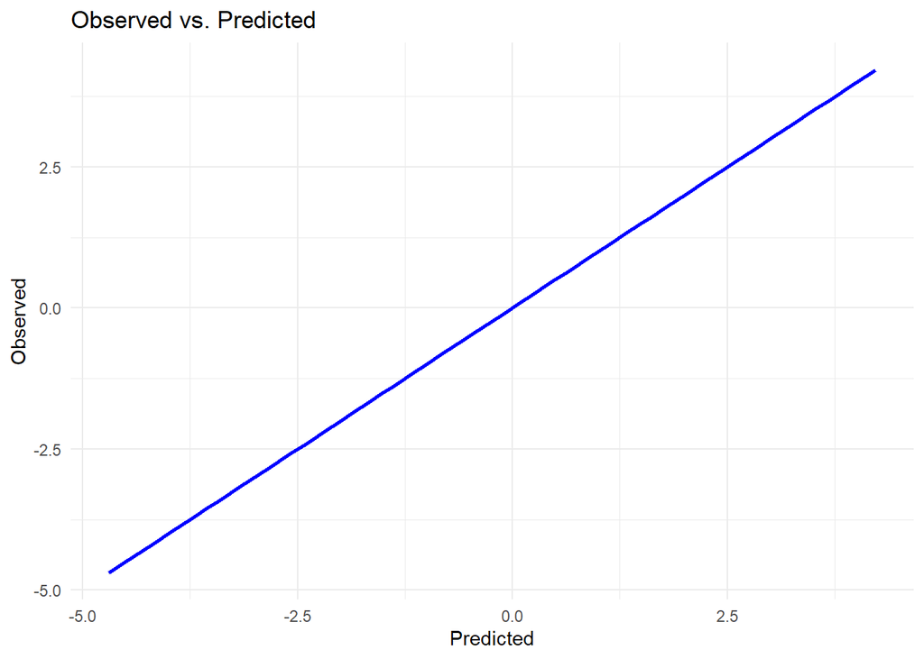

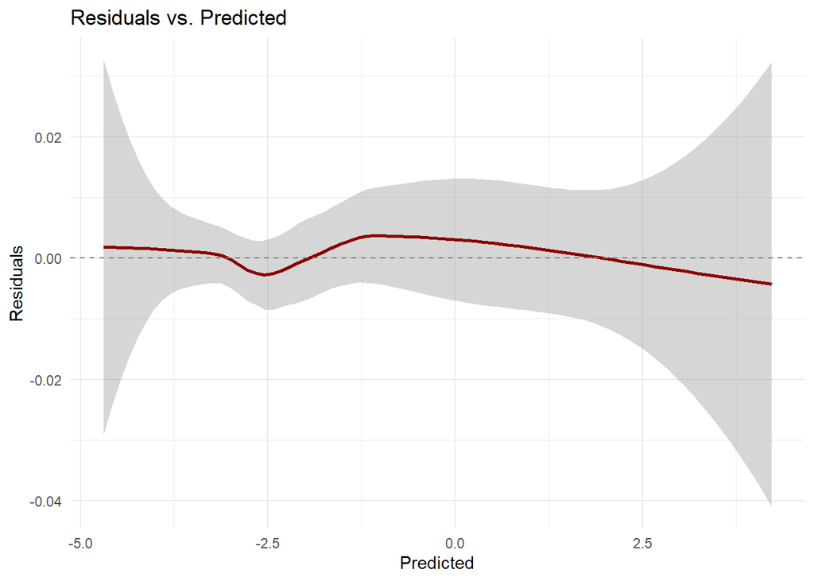

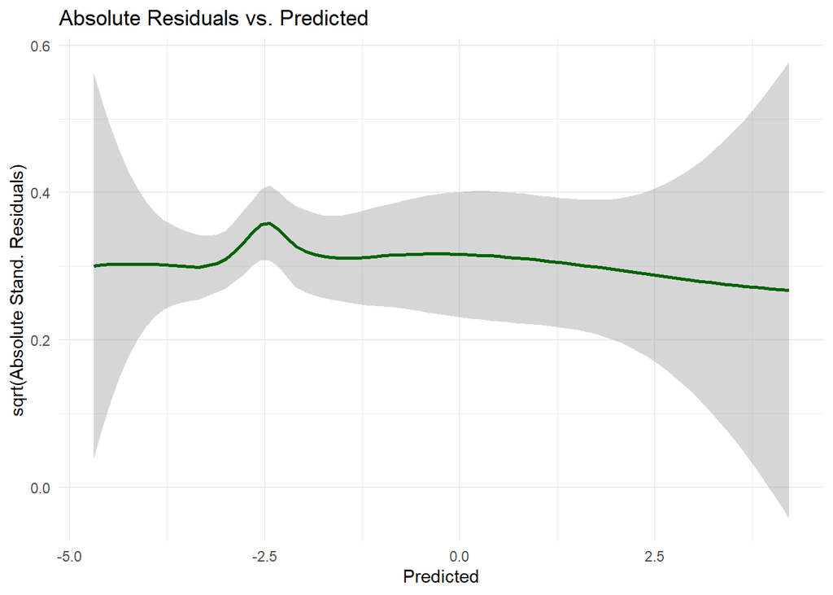

```r
plot_lm_diagnostics(fit_M2)
plot_lm_diagnostics(fit_M2, point=F, hist=F)
```

Remark: this is exactly the result predicted by Kepler’s law! The regression coefficients are essentially 0.332 and 0.667 on the log scale. The regression approximately yields

$$log(semimajoraxis) \propto 1/3\cdot \log(hoststarmass) + 2/3 \cdot log(period)$$

which could be written as

$$semimajoraxis \propto (hoststarmass \times period^2)^{1/3}$$
.

### Interlude

Comparing Model 2 and Model 1rob, we see that Model 2 has much higher $R^2$ (0.9989 compared to 0.9564) and less problems with residual diagnostics. Hence the decision was made to change the analysis plan such that we work with log-transformed data for most analyses.

### Model 3: MFP

Using the analysis set with log-transformed data (`analysis_log`).

```r
library(mfp2)
fit_M3 <- mfp2(data=analysis_log, semimajoraxis ~ fp(hoststar_mass) + fp(period) + fp(mass) + fp(hoststar_temperature) + fp(radius) + fp(eccentricity) + fp(hoststar_radius) + fp(hoststar_metallicity) + binaryflag, df=4, criterion="bic")
```

```
i Initial degrees of freedom:
   hoststar_mass period mass hoststar_temperature radius eccentricity
df             4      4    4                    4      4            4
   hoststar_radius hoststar_metallicity binaryflag
df               4                    4          1

i Visiting order: period, hoststar_mass, hoststar_radius, hoststar_metallicity, hoststar_temperature, mass, eccentricity, radius, binaryflag

---------------------
i Running MFP Cycle 1
---------------------

Variable: period (keep = FALSE)
                 Powers    DF    BIC
null             NA        10    3162.3
linear           1         11    -3023.8
FP1              0.5       12    326.2
FP2              1, 3      14    -3003.5
Selected: linear

Variable: hoststar_mass (keep = FALSE)
                 Powers    DF    BIC
null             NA        10    -2697.1
linear           1         11    -3023.8
FP1              0.5       12    -2953.8
FP2              1, 1      14    -3008.0
Selected: linear

Variable: hoststar_radius (keep = FALSE)
                 Powers    DF    BIC
null             NA        10    -3025.3
linear           1         11    -3023.8
FP1              0.5       12    -3022.3
FP2              -2, 0     14    -3010.8
Selected: null

Variable: hoststar_metallicity (keep = FALSE)
                 Powers    DF    BIC
null             NA        9     -3030.0
linear           1         10    -3025.3
```

[output cut: 102 more lines]

```
Variable: radius (keep = FALSE)
                 Powers    DF    BIC
null             NA        4     -3062.1
linear           1         5     -3055.5
FP1              3         6     -3048.7
FP2              3, 3      8     -3035.2
Selected: null

Variable: binaryflag (keep = FALSE)
                 Powers    DF    BIC
null             NA        4     -3062.1
linear           1         5     -3055.3
Selected: null

i Fractional polynomial fitting algorithm converged after 2 cycles.
```

```r
fit_M3
```

```
Shifting, Scaling and Centering of covariates
                         shift scale center
period                0.806143    10   TRUE
hoststar_mass         2.419778     1   TRUE
hoststar_radius       2.112159     1   TRUE
hoststar_metallicity  2.525729     1   TRUE
hoststar_temperature  0.000000     1   TRUE
mass                 11.766875    10   TRUE
eccentricity          7.246178     1   TRUE
radius                4.108266     1   TRUE
binaryflag            0.000000     1   TRUE

Final Multivariable Fractional Polynomial for y
                     df_initial select alpha selected df_final power1
period                        4    BIC   BIC     TRUE        1      1
hoststar_mass                 4    BIC   BIC     TRUE        1      1
hoststar_radius               4    BIC   BIC    FALSE        0     NA
hoststar_metallicity          4    BIC   BIC    FALSE        0     NA
hoststar_temperature          4    BIC   BIC    FALSE        0     NA
mass                          4    BIC   BIC    FALSE        0     NA
eccentricity                  4    BIC   BIC    FALSE        0     NA
radius                        4    BIC   BIC    FALSE        0     NA
binaryflag                    1    BIC   BIC    FALSE        0     NA

MFP algorithm convergence: TRUE

Call:  glm(formula = y ~ ., family = family, data = data, weights = weights,
    offset = offset, x = TRUE, y = TRUE)

Coefficients:
    (Intercept)         period.1  hoststar_mass.1
        -2.3487           6.6683           0.3322

Degrees of Freedom: 938 Total (i.e. Null);  936 Residual
Null Deviance:      1893
Residual Deviance: 2.048    AIC: -3081
```

```r
summary(fit_M3)
```

```
Call:
glm(formula = y ~ ., family = family, data = data, weights = weights,
    offset = offset, x = TRUE, y = TRUE)

Coefficients:
                 Estimate Std. Error  t value Pr(>|t|)
(Intercept)     -2.348667   0.001526 -1538.69   <2e-16 ***
period.1         6.668307   0.007260   918.45   <2e-16 ***
hoststar_mass.1  0.332248   0.003995    83.16   <2e-16 ***
---
Signif. codes:  0 '***' 0.001 '**' 0.01 '*' 0.05 '.' 0.1 ' ' 1

(Dispersion parameter for gaussian family taken to be 0.002187799)

    Null deviance: 1893.0816  on 938  degrees of freedom
Residual deviance:    2.0478  on 936  degrees of freedom
AIC: -3081.5

Number of Fisher Scoring iterations: 2
```

The MFP model confirms the Kepler law model - it identifies hoststar_mass and period with no transformation (except the log) as the only influential variables. The regression coefficients are in line with the Kepler law.

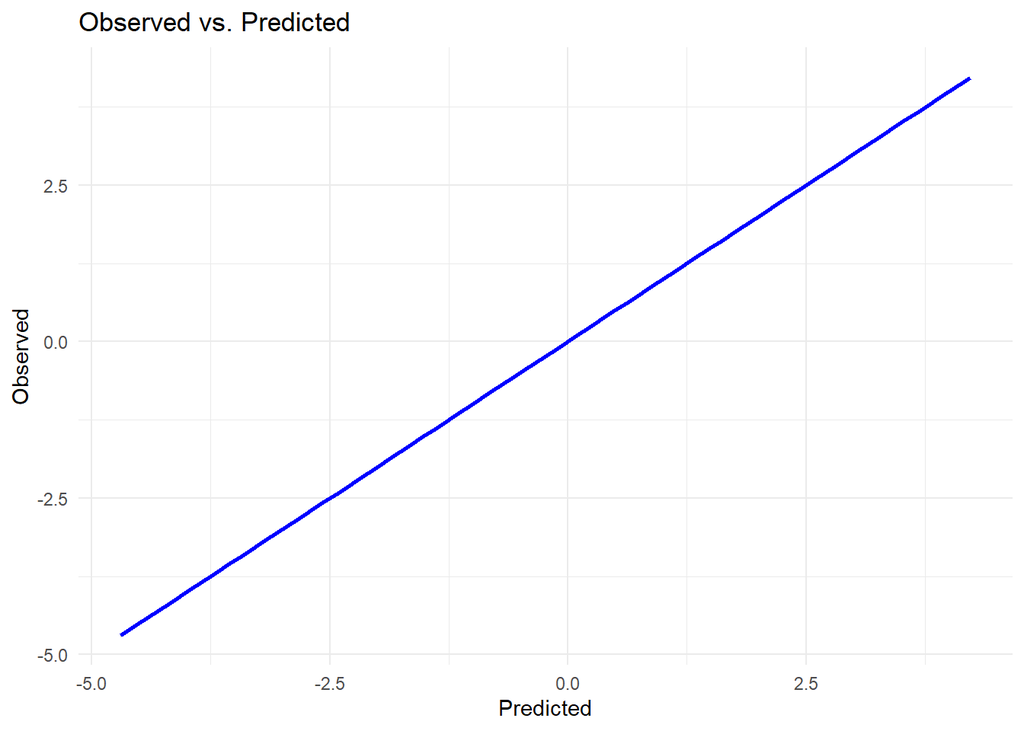

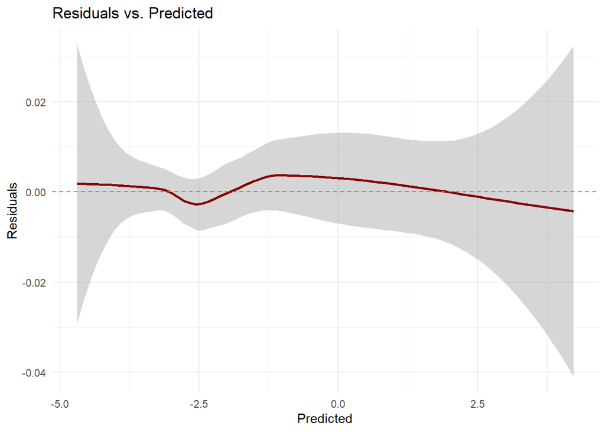

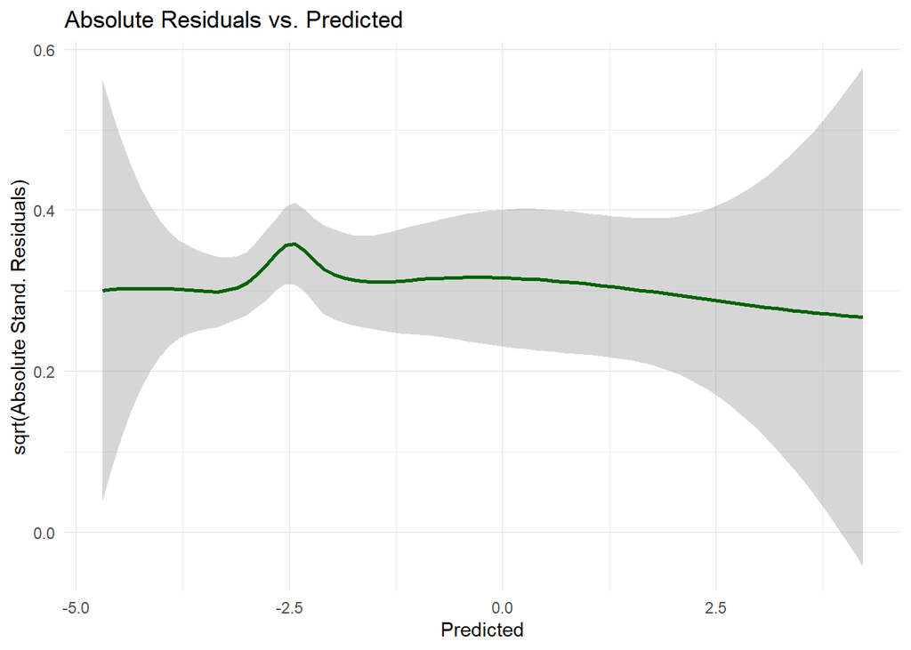

```r
plot_lm_diagnostics(fit_M3)
plot_lm_diagnostics(fit_M3, point=F, hist=F)
```

The residual plots do not give rise to any major concerns.

### Model 4: Symbolic regression

```r
library(gramEvol)
if(do_symbolic) {

  pow2 <- function(X) X^2
  pow3 <- function(X) X^3
  pow1_2 <- function(X) X^(1/2)
  pow1_3 <- function(X) X^(1/3)

  ruleDef <- list(expr = grule(op(expr, expr), func(expr), var),
                  func = grule(log, identity, pow2, pow3, pow1_2, pow1_3),
                  op = grule('+', '-', '*', '/'),
                  var = grule(analysis_log$period,
                              analysis_log$mass,
                              analysis_log$hoststar_mass,
                              analysis_log$hoststar_temperature,
                              analysis_log$radius,
                              analysis_log$eccentricity,
                              analysis_log$hoststar_radius,
                              analysis_log$hoststar_metallicity,
                              analysis_log$binaryflag),
                  n = gvrule(1:4))

  grammarDef <- CreateGrammar(ruleDef)
  #GrammarRandomExpression(grammarDef, 6)

  null_var <- var(analysis_log$semimajoraxis)

  SymRegFitFunc <- function(expr) {
    result <- eval(expr)
    if (any(is.nan(result)))
      return(Inf)
  #  calib <- lm(analysis_log$semimajoraxis ~ result)
    resid_var = mean((analysis_log$semimajoraxis - result)^2)
    Unexpl_var = resid_var/null_var
    return(Unexpl_var)
  }

  set.seed(7123981)
  ge <- GrammaticalEvolution(grammarDef=grammarDef, evalFunc=SymRegFitFunc,
                             terminationCost = 0.01,
                             iterations = 500,
                             disable.warnings=TRUE,
                             optimizer = "ga",
                             max.depth =3)
  print(ge, sequence=TRUE)

  ges <- GrammaticalExhaustiveSearch(grammar = grammarDef, evalFunc = SymRegFitFunc, max.depth=3, terminationCost = 1)
} else {
  load("symbolic_results.Rdata")
}
print(ges)
```

```
GE Search Results:
  Expressions Tested: 387
  Best Chromosome:    0 0 2 2 2 5
  Best Expression:    analysis_log$hoststar_mass + analysis_log$eccentricity
  Best Cost:          1.061677
```

The model ended up in the expression `hoststar_mass + eccentricity` (recall, both variables were on the log scale) which yields a variance of residuals that is about 1.06 fold the original variance of log(semimajoraxis). This means the model did not converge to the Kepler law, it did not even yield a residual variance that was smaller than the variance of the dependent variable. An exhaustive enumeration of all possible expressions did not yield a better model. This may be due to insufficient implementation of the symbolic regression model. Finally, it was decided to skip symbolic regression for this example.

### Model 4 alternative: using FPs as grammar, linear combination, and an FP1 for outcome transformation

In this model building strategy, we use FP as the grammar, offering the set of powers $\{-2, -1, -1/2, 0, 1/2, 1, 2, 3\}$, where 0 refers to $\log$. We also apply FP to the outcome, which means we wrap a loop over the transformations around the ´mfp´ call and evaluate the models by inverting the outcome transformation and applying it to the linear predictor. However, for the outcome we use a symmetric power set, which seems more reasonable for the right-skewed data: $\{-1, -0.5, -1/3, 0, 1/3, 0.5, 1\}$.

For this analysis, we chose to use the non-transformed data set, first including the two influential points. The Kepler Law would be within the search space in the model.

```r
require(mfp2)
out_trans <- c(-1, -0.5, -1/3, 0, 1/3, 0.5, 1)

# define functions for outcome transformation and inverse transformation
FPY <- function(y, p){
  if(p !=0) return(y^p)
  else return(log(y))
}
IFPY <- function(mu, p){
  if(p !=0) return(mu^(1/p))
  else return(exp(mu))
}


ss_ymfp <- matrix(0,length(out_trans), 3)  # 3 columns: SS, df of model, BIC
colnames(ss_ymfp) <- c("SumSq", "DF", "BIC")


fits <- vector(mode="list", length = length(out_trans))
pred_ymfp <- matrix(0, nrow(analysis_set), length(out_trans))
mape <- vector(mode="numeric", length(length(out_trans)))


# loop over outcome transformations
for(j in 1:length(out_trans)){
  # transform outcome
  y_tmp <- FPY(analysis_set$semimajoraxis, out_trans[j])
  # fit MFP model with transformed outcome
  fit_tmp <-    mfp2(data=analysis_set, y_tmp ~ fp(hoststar_mass) + fp(period) + fp(mass) + fp(hoststar_temperature) + fp(radius) + fp(eccentricity) + fp(hoststar_radius) + fp(hoststar_metallicity) + binaryflag, df=4, criterion="bic", verbose=FALSE)
  fits[[j]] <- fit_tmp
  # evaluate sum of squares with inversely transformed linear predictor
  pred_ymfp[,j] <- IFPY(predict(fit_tmp, newdata=analysis_set), out_trans[j])
  ss_ymfp[j,1] <- sum((pred_ymfp[,j] - analysis_set$semimajoraxis)^2)
  ss_ymfp[j,2] <- sum(fit_tmp$fp_terms[,"df_final"])
  ss_ymfp[j,3] <- ss_ymfp[j,1] + log(fit_tmp$df.null+1) * ss_ymfp[j,2]   # bic
  mape[j] <- median(abs(analysis_set$semimajoraxis - pred_ymfp[,j]))
}


# evaluate results
round(cbind(out_trans, ss_ymfp),1)
```

```
     out_trans   SumSq DF     BIC
[1,]      -1.0 16312.0 10 16380.4
[2,]      -0.5 15273.9 11 15349.2
[3,]      -0.3  5997.3 16  6106.8
[4,]       0.0     0.4  4    27.7
[5,]       0.3   823.9 12   906.0
[6,]       0.5    85.0 14   180.8
[7,]       1.0    41.3 10   109.7
```

```r
cbind(out_trans, mape)
```

```
      out_trans         mape
[1,] -1.0000000 0.0020796987
[2,] -0.5000000 0.0012372427
[3,] -0.3333333 0.0019120992
[4,]  0.0000000 0.0001288305
[5,]  0.3333333 0.0067803313
[6,]  0.5000000 0.0081356861
[7,]  1.0000000 0.0493376820
```

```r
# summary of best fit:
best_index <- which.min(ss_ymfp[,3])
fits[[best_index]]
```

```
Shifting, Scaling and Centering of covariates
                        shift scale center
period               0.000000 1e+05   TRUE
eccentricity         0.129317 1e+00   TRUE
mass                 0.000000 1e+01   TRUE
radius               0.000000 1e+00   TRUE
binaryflag           0.000000 1e+00   TRUE
hoststar_mass        0.000000 1e+00   TRUE
hoststar_metallicity 0.920000 1e+00   TRUE
hoststar_radius      0.000000 1e+01   TRUE
hoststar_temperature 0.000000 1e+03   TRUE

Final Multivariable Fractional Polynomial for y
                     df_initial select alpha selected df_final power1
period                        4    BIC   BIC     TRUE        2      0
eccentricity                  4    BIC   BIC    FALSE        0     NA
mass                          4    BIC   BIC    FALSE        0     NA
radius                        4    BIC   BIC    FALSE        0     NA
binaryflag                    1    BIC   BIC    FALSE        0     NA
hoststar_mass                 4    BIC   BIC     TRUE        2      0
hoststar_metallicity          4    BIC   BIC    FALSE        0     NA
hoststar_radius               4    BIC   BIC    FALSE        0     NA
hoststar_temperature          4    BIC   BIC    FALSE        0     NA

MFP algorithm convergence: TRUE

Call:  glm(formula = y ~ ., family = family, data = data, weights = weights,
    offset = offset, x = TRUE, y = TRUE)

Coefficients:
    (Intercept)         period.1  hoststar_mass.1
        -2.3487           0.6668           0.3322

Degrees of Freedom: 938 Total (i.e. Null);  936 Residual
Null Deviance:      1893
Residual Deviance: 2.048    AIC: -3081
```

With this approach, model 4 applies a log transformation to the outcome and two log transformations to hoststar_mass and period, and such finds the Kepler model. The second-best model is model 7, with untransformed outcome variable. That model has considerably more complex transformations for the variables:

- FP(0.5,1) for period
- FP(-2) for mass
- FP(-0.5) for hoststar_radius
- linear hoststar_mass
- linear eccentricity

This could be a result from the sum of squares being highly influenced by the two high-leverage observations.

The importance of the variables, as expressed by standardized regression coefficients, is as follows:

```r
# Helper function to obtain partial fit for a variable

#Helper function to compute standardised coefficients (sd(beta*FP(X)))

partial <- function(model, data, adj_stat = mean){
  variables <- rownames(model$transformations)
  adj_to <- apply(data[,variables], 2, adj_stat)
  partial <- matrix(NA, nrow(data), length(variables))
  colnames(partial) <- variables
  nv <- length(variables)
  betas <- 0*(1:nv)
  names(betas) <- variables
  for(j in 1:nv){
    variable <- variables[j]
    scale <- model$transformations[variable,2]
    shift <- model$transformations[variable, 1]
    pow <- model$fp_powers[[variable]]
    var_pre <- (c(adj_to[variable],data[[variable]]) +shift)/ scale
    value <- rep(0, length(var_pre))
    if(!is.na(pow[1])) {
      beta <- coef(model)[grepl(variable, names(coef(model)))]
      var1 <- var_pre**pow[1]
      if(pow[1]==0) var1 <- log(var_pre)
      value <- var1 * beta[1]
      if(length(pow)==2) {
        if(pow[2] == pow[1]) var2 <- var1 * log(var_pre)
        else var2 <- var_pre**pow[2]
        value <- value + var2 * beta[2]
      }
    }
    value <- value - value[1]
    partial[,j] <- value[-1]
  }
  return(partial)
}



#Helper function to compute standardised coefficients (sd(beta*FP(X)))

beta_std <- function(model, data){
  variables <- rownames(model$transformations)
  nv <- length(variables)
  betas <- 0*(1:nv)
  names(betas) <- variables
  for(j in 1:nv){
    variable <- variables[j]
    scale <- model$transformations[variable,2]
    shift <- model$transformations[variable, 1]
    pow <- model$fp_powers[[variable]]
    if(is.na(pow[1])) beta[j] <- 0
    else {
      beta <- coef(model)[grepl(variable, names(coef(model)))]
      var_pre <- (data[[variable]] +shift)/ scale
      var1 <- var_pre**pow[1]
      if(pow[1]==0) var1 <- log(var_pre)
      value <- var1 * beta[1]
      if(length(pow)==2) {
        if(pow[2] == pow[1]) var2 <- var1 * log(var_pre)
        else var2 <- var_pre**pow[2]
        value <- value + var2 * beta[2]
      }
      betas[j] <- sd(value)
    }
  }
  return(-sort(-betas))
}

cat("Standardized betas for Linear outcome\n")
```

```
Standardized betas for Linear outcome
```

```r
beta_std(fits[[7]], analysis_set)
```

```
              period                 mass        hoststar_mass
          3.91821758           0.10740711           0.09423650
     hoststar_radius         eccentricity hoststar_metallicity
          0.04974887           0.03292858           0.00000000
          binaryflag               radius hoststar_temperature
          0.00000000           0.00000000           0.00000000
```

```r
cat("\nStandardized betas for Log outcome\n")
```

```
Standardized betas for Log outcome
```

```r
beta_std(fits[[4]], analysis_set)
```

```
              period        hoststar_mass         eccentricity
           1.4057520            0.1272861            0.0000000
                mass               radius           binaryflag
           0.0000000            0.0000000            0.0000000
hoststar_metallicity      hoststar_radius hoststar_temperature
           0.0000000            0.0000000            0.0000000
```